# Police Search Practices Across Three States

Data Science Portfolio - December 2025

Eli Della Bitta

## The Question

Do police search practices look different across states?

I wanted to find out if some states search drivers more often than others during traffic stops, and whether searching more frequently actually leads to finding more contraband.

## Why Look at This?

Understanding how police conduct searches matters because:

- It shows us different approaches to law enforcement
- We can see which strategies are more effective
- It raises questions about fairness and individual rights
- The differences between states are pretty significant

## The Data

**Stanford Open Policing Project**

- Traffic stop data from California, Texas, and Illinois
- Looking at 2015-2016
- Includes millions of traffic stops
- Tracks both searches and whether contraband was found

## Search Rates: How Often Do Police Search?

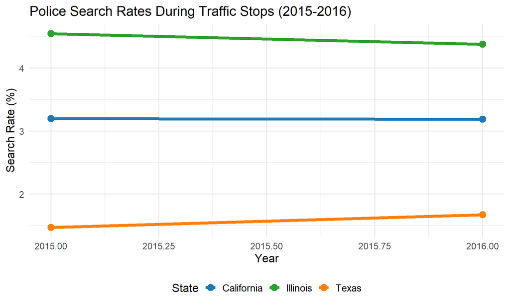

## What I Found: Search Rates

Illinois searches most frequently - around **4.5%** of all traffic stops result in a search.

California is in the middle at about **3.2%** of stops.

All three states show consistent patterns across both years.

## The Follow-Up Question

So we know Illinois searches most often, Texas searches least often…

**But which approach actually finds more contraband?**

A “hit rate” tells us what percentage of searches actually found something.

## Hit Rates: When Searches Find Contraband

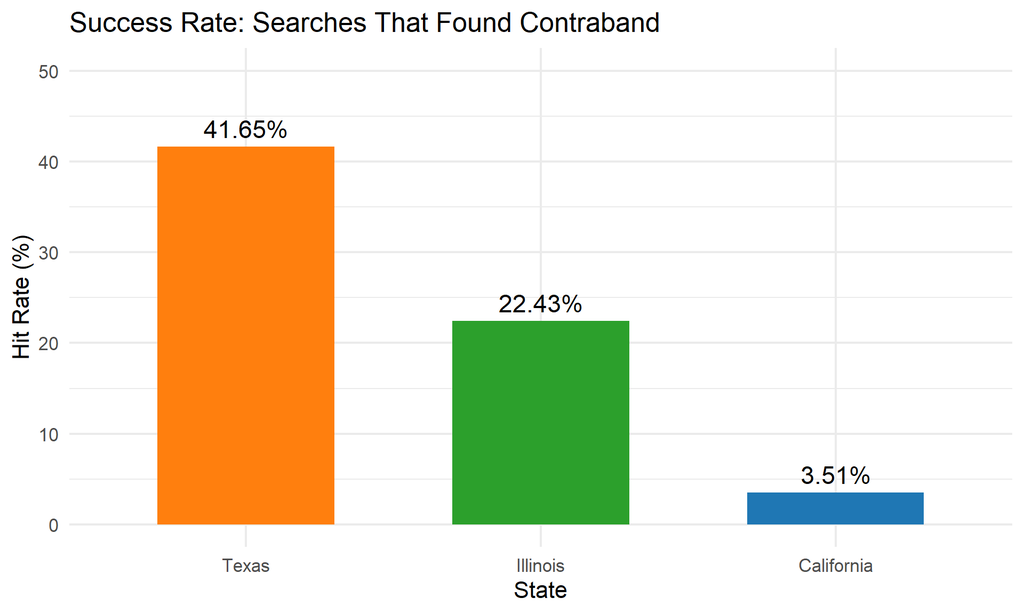

## The Big Finding

The state that searches the least (Texas) is actually the most successful per search. The state that searches the most (Illinois) has a lower success rate.

## What This Actually Means

More searches doesn’t equal better results.

This suggests different standards for what justifies a search. Texas appears to have stricter criteria, while Illinois and California may be using broader reasons to initiate searches.

## All Three States Compared

Complete Comparison (2015-2016)

| State | Search Rate (%) | Total Stops | Hit Rate (%) |
| --- | --- | --- | --- |
| Illinois | 4.46 | 4192128 | 22.43 |
| California | 3.20 | 5957628 | 3.51 |
| Texas | 1.57 | 3577592 | 41.65 |

## Key Takeaways

**California stands out for the wrong reasons:** While searching 3.2% of stops (more than Texas), California only finds contraband 3.5% of the time - meaning **96.5% of searches turn up nothing**.

Illinois falls in the middle - searches most frequently (4.5%) with moderate success (22.4%).

**The big question:** Why is California’s hit rate so incredibly low? This suggests potential issues with how they’re deciding when to search.

## Why This Matters

These aren’t small differences - they’re huge.

California’s 3.5% hit rate means that in nearly 19 out of 20 searches, nothing is found. This raises some questions about the criteria being used.

The data suggests there might be better and worse ways to approach searches during traffic stops, with real implications for both effectiveness and individual rights.

## Questions?

Thanks for listening!

**Data Source:**

Pierson et al. (2020). “A large-scale analysis of racial disparities in police stops across the United States.” *Nature Human Behaviour*

Stanford Open Policing Project: openpolicing.stanford.edu